Indicadores migratorios  
Hungría

[Observatorio Permanente de la Inmigración (OPI) - S.G de Análisis Migratorio (SGAM)](https://inclusion.seg-social.es/web/opi/estadisticas)

Junio 2023

1. Ciudadanos con documentación en vigor

2. Empadronados

3. Perfil sociodemográfico y distribución territorial

4. Afiliación en alta laboral y paro registrado

5. Nacionalizados españoles por residencia

6. Evolución del flujo de documentación de residencia

7. Población española residente en Hungría

# 1. Ciudadanos con documentación en vigor

A fecha 31/12/2022 constaban **21.214 ciudadanos de nacionalidad húngara en España documentados** con certificado de registro en régimen de Libre Circulación por ser ciudadanos de la UE/AELC.

Nacionales de Hungría con certificado de registro según modalidad de residencia y motivo de expedición*. 31/12/2022

| Modalidad | Personas | % |
| --- | --- | --- |
| TOTAL | 21.214 | 100 |
| Titular UE-RU. Temporal. Motivo de residencia no determinado | 8.580 | 40 |
| Titular UE-RU. Temporal. Trabajo por cuenta ajena | 4.531 | 21 |
| Titular UE-RU. Permanente | 3.008 | 14 |
| Titular UE-RU. Temporal. Residencia no lucrativa | 2.032 | 10 |
| Titular UE-RU. Temporal. Familiar | 1.514 | 7 |
| Titular UE-RU. Temporal. Trabajo por cuenta propia | 811 | 4 |
| Titular UE-RU. Temporal. Estudiante | 738 | 3 |

(*) La información sobre el motivo de expedición del certificado de registro es limitada ya que la obligación de recogerlo no existió hasta 2011. Y para los que disponen de residencia permanente, tampoco se conserva el motivo original por el que se expidió el certificado, antes de que la residencia deviniera permanente (pasados los cinco primeros años). Además, el motivo se refiere solo al motivo en el momento de la primera inscripción, pudiendo haberse modificado en el tiempo sin que se registre con posterioridad.

La comunidad de Hungría representa un **1% de todos los ciudadanos de la UE/AELC con documentación de residencia en vigor en España.**

| Tipo documentación | Todas las nacionalidades | Nacionales de UE/AELC | % UE/AELC respecto Total | NACIONALES DE HUNGRÍA | % Hungría respecto UE/AELC |
| --- | --- | --- | --- | --- | --- |
| TOTAL | 6.493.147 | 2.810.885 | 43 | 21.214 | 1 |
| Autorización | 2.690.247 | 0 | 0 | 0 |  |
| Certificado de registro y TIE-Acuerdo de retirada (titular) | 3.213.332 | 2.810.885 | 87 | 21.214 | 1 |
| Tarjeta familiar de UE-RU y TIE-Acuerdo de retirada (familiar) | 589.568 | 0 | 0 | 0 |  |

Fuente: [OPI - SGAM](https://inclusion.seg-social.es/web/opi/estadisticas/catalogo/extranjeros_con_certificado)

# 2. Empadronados

| Documentación | Personas |
| --- | --- |
| Empadronados a 01/01/2022 | 10.986 |
| Con documentación de residencia a 31/12/2021 | 20.043 |
| Documentados menos empadronados | 9.057 |

Fuente: [Padrón Continuo - INE](https://www.ine.es/dyngs/INEbase/es/operacion.htm?c=Estadistica_C&cid=1254736177012&menu=ultiDatos&idp=1254734710990)

# 3. Perfil sociodemográfico y distribución territorial

Nacionales de Hungría con documentación de residencia según sexo y grupo de edad. 31/12/2022

| TOTAL | Hombres | % Hombres | Mujeres | % Mujeres |
| --- | --- | --- | --- | --- |
| 21.214 | 10.124 | 48 | 11.090 | 52 |

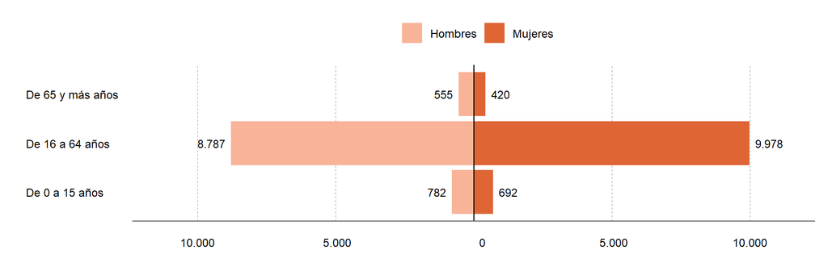

Nacionales de Hungría con documentación de residencia según provincia de residencia, 31/12/2022. Cifras absolutas y porcentaje sobre el total de extranjeros residentes de nacionalidad húngara

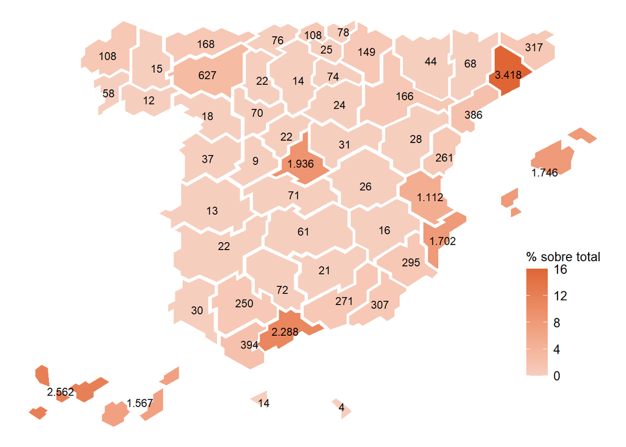

Fuente: [OPI - SGAM](https://inclusion.seg-social.es/web/opi/estadisticas/catalogo/extranjeros_con_certificado)

# 4. Afiliación en alta laboral y paro registrado

4.1 Régimen de afiliación a la Seguridad Social de nacionales de Hungría a 28/04/2023

| Régimen | Afiliados de Hungría | Afiliados UE/AELC | % Hungría sobre UE/AELC |
| --- | --- | --- | --- |
| TOTAL | 5.765 | 884.639 | 1 |
| Régimen General | 4.085 | 616.932 | 1 |
| R.E. Autónomos/as | 1.581 | 169.916 | 1 |
| R.G. - S.E. Empleados/as hogar | 62 | 33.604 | 0 |
| R.G. - S.E. Agrario | 33 | 62.928 | 0 |
| R.E. Mar (cuenta ajena) | 4 | 1.103 | 0 |
| R.E. Mar (cuenta propia) | 0 | 131 | 0 |
| R.E. Minería carbón | 0 | 25 | 0 |

Afiliados nacionales de Hungría en alta laboral según régimen y sexo. 28/04/2023

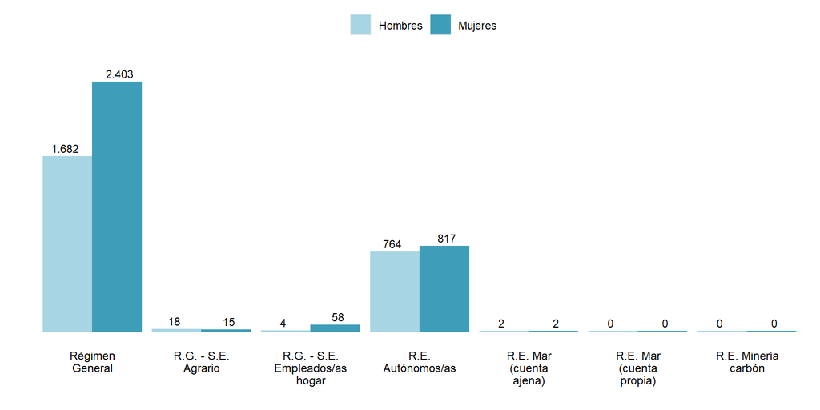

Fuente: [Seguridad Social - MISSM](https://www.seg-social.es/wps/portal/wss/internet/EstadisticasPresupuestosEstudios/Estadisticas/EST8/EST10/EST305/EST307/EST314)

4.2 Parados registrados en el SEPE nacionales de Hungría (abril 2023)

Hay en España 618 parados registrados nacionales de Hungría, 218 (35%) hombres y 400 (65%) mujeres.

| TOTAL | Sexo Hombres | Sexo Mujeres | Grupo de edad 16-24 años | Grupo de edad 25-34 años | Grupo de edad 35-44 años | Grupo de edad 45-54 años | Grupo de edad 55 y más años |
| --- | --- | --- | --- | --- | --- | --- | --- |
| 618 | 218 | 400 | 18 | 105 | 201 | 205 | 89 |
| % | 35 | 65 | 3 | 17 | 33 | 33 | 14 |

Parados registrados en el SEPE nacionales de Hungría según comunidad autónoma, abril 2023. Cifras absolutas y porcentaje sobre el total de parados extranjeros registrados residentes de nacionalidad húngara

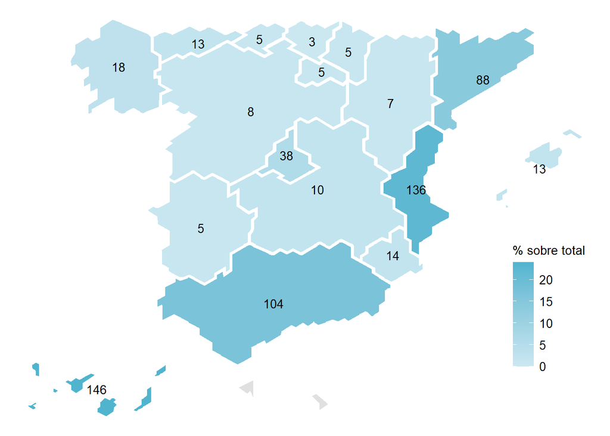

Fuente: [Servicio Público de Empleo Estatal (SEPE)](https://www.sepe.es/HomeSepe/que-es-el-sepe/estadisticas.html)

# 5. Nacionalizados españoles por residencia

Además de la adquisición originaria, el Código Civil considera diferentes modos de **adquisición de la nacionalidad española**:

- **Por adopción**: los extranjeros menores de 18 años adoptados por un español.
- **Por opción**:  
  - Las personas que estén o hayan estado sujetas a la patria potestad de un español.  
  - Las personas cuyo padre o madre hubiera sido originariamente español y nacido en España.  
  - Las personas cuya filiación (identificación de quiénes son sus progenitores) o nacimiento en España se determine después de haber cumplido los 18 años.  
  - Los extranjeros mayores de 18 años adoptados por un español.
- **Por carta de naturaleza**: otorgada discrecionalmente mediante Real Decreto cuando en el interesado concurran circunstancias especiales.
- **Por residencia**, otorgada por el Ministerio de Justicia cuando concurran los siguientes requisitos:  
  1. Haber residido en España un plazo de tiempo que varía según el supuesto.  
  2. La residencia debe ser legal, continuada e inmediatamente anterior a la solicitud.  
  3. El interesado deberá justificar buena conducta cívica y suficiente grado de integración en la sociedad española.
- **Posesión de Estado**: posesión y utilización continuada de la nacionalidad española durante diez años con buena fe y basada en un título inscrito en el Registro Civil.

El 81% del total de adquisiciones de nacionalidad española (no originaria) registradas en el Registro Civil desde 2013 han sido por residencia. En 2022, último periodo publicado por el INE, ese porcentaje fue del 87%.

**Desde 2009 se han nacionalizado españoles por residencia un total de 304 personas con nacionalidad previa húngara.**

En 2022 obtuvieron la nacionalidad por residencia 15 personas.

Evolución de las concesiones de nacionalidad española por residencia a ciudadanos de Hungría. 2009-2022

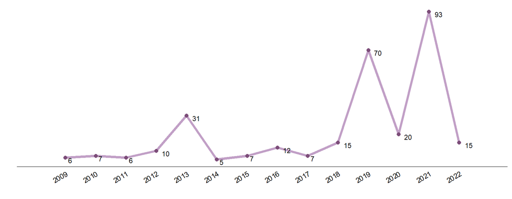

Nota: En 2017 hubo una reducción generalizada de las concesiones de nacionalidad por causas administrativas.

Concesiones de nacionalidad española por residencia a ciudadanos de Hungría según plazo exigido / motivo. 2022

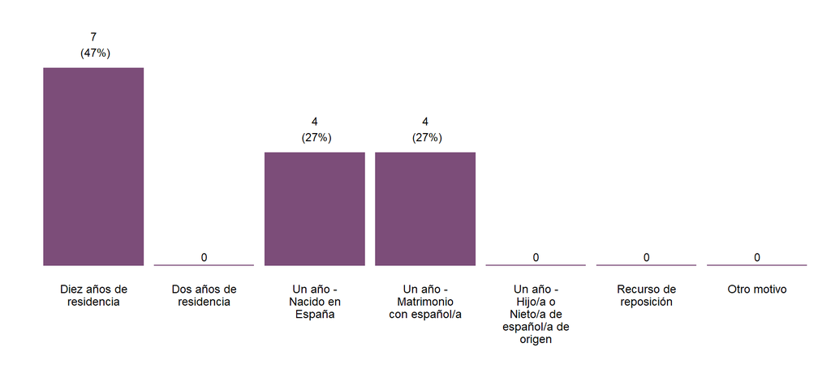

Nota: Existen casos en los que la nacionalidad de origen grabada no coincide con la vía de acceso a la nacionalidad española que debería corresponder según la legislación. Sin embargo, en este momento no se dispone de suficiente información para su correcta depuración.

Concesiones de nacionalidad española por residencia a ciudadanos de Hungría según sexo y edad. 2022

| TOTAL | Hombres | % Hombres | Mujeres | % Mujeres |
| --- | --- | --- | --- | --- |
| 15 | 5 | 33 | 10 | 67 |

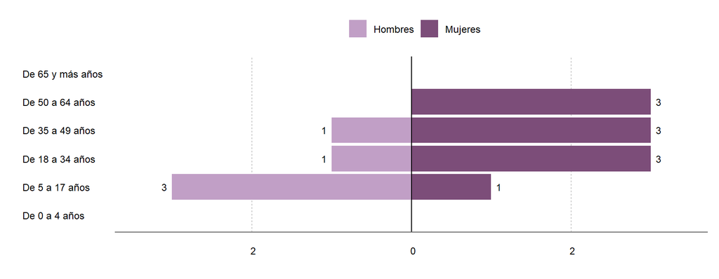

Fuente: [INE](https://www.ine.es/dyngs/INEbase/es/operacion.htm?c=Estadistica_C&cid=1254736177001&menu=resultados&idp=1254735573002), [OPI-SGAM](https://inclusion.seg-social.es/web/opi/estadisticas/catalogo/concesiones_nacionalidad)

# 6. Evolución del flujo de documentación de residencia

En los últimos 5 años se han expedido **certificados de registro a nacionales de Hungría, según estos motivos:**

| Motivo | 2017 | 2018 | 2019 | 2020 | 2021 |
| --- | --- | --- | --- | --- | --- |
| TOTAL | 1.248 | 1.405 | 1.546 | 1.101 | 1.244 |
| Titular UE-RU. Temporal | 995 | 1.156 | 1.271 | 922 | 988 |
| Titular UE-RU. Permanente | 253 | 249 | 275 | 178 | 255 |
| Familiar de UE-RU. Temporal | 0 | 0 | 0 | 1 | 1 |

Nota: existen casos en los que la nacionalidad grabada es incompatible con el motivo de expedición del certificado de registro, pero en estos momentos no se dispone de suficiente información para su correcta depuración.

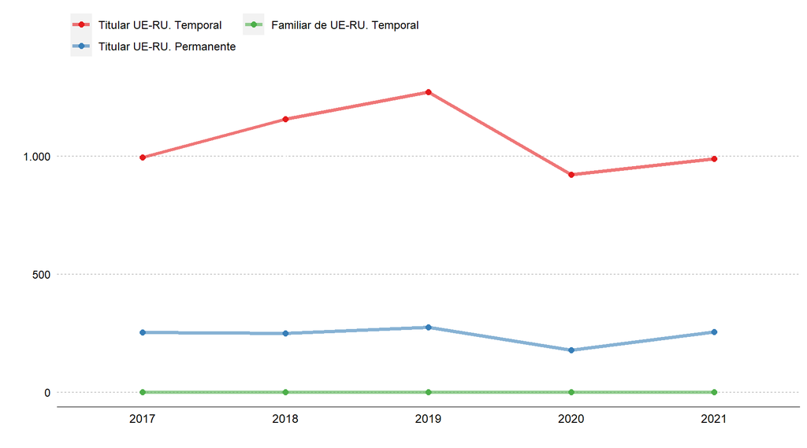

Fuente: [OPI - SGAM](https://inclusion.seg-social.es/web/opi/estadisticas/catalogo/flujo_autorizaciones)

# 7. Población española residente en Hungría

**A 01/01/2023, último dato publicado por el INE, había 818 españoles residentes en Hungría** inscritos en el fichero central del Padrón de españoles residentes en el extranjero (PERE); suponen el 0% de todos los españoles residentes en países de Europa.

| TOTAL | Hombres | % Hombres | Mujeres | % Mujeres |
| --- | --- | --- | --- | --- |
| 818 | 531 | 65 | 287 | 35 |

Evolución de los españoles residentes en Hungría. 2009-2023

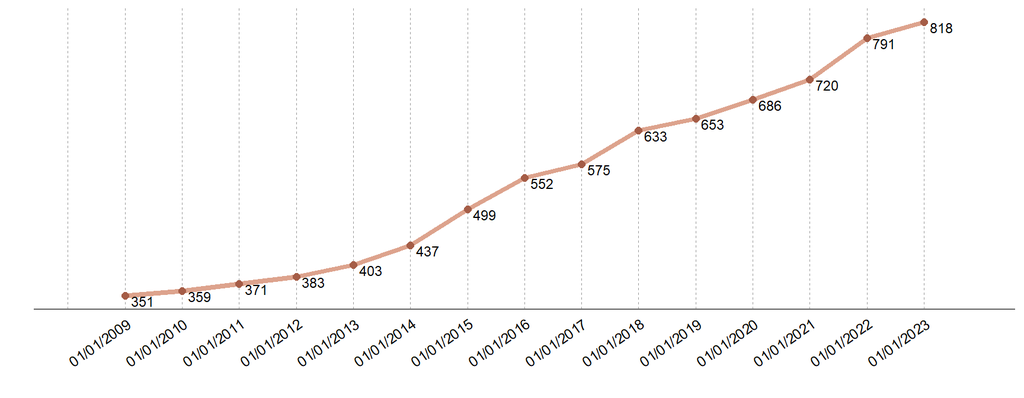

Fuente: [PERE - INE](https://www.ine.es/dyngs/INEbase/operacion.htm?c=Estadistica_C&cid=1254736177014&menu=resultados&secc=1254736195474&idp=1254734710990)